# R Notebook

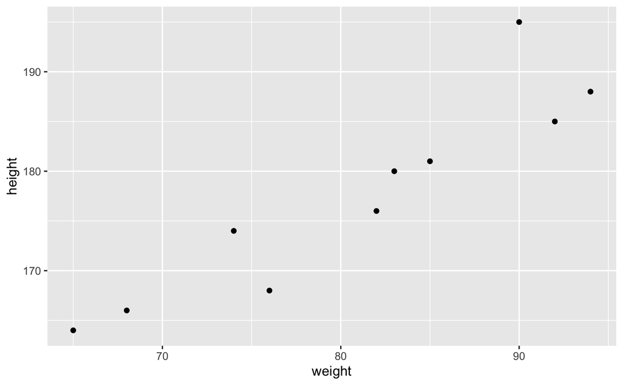

```r
library(tidyverse)

height <- c(176, 164, 181, 168, 195, 185, 166, 180, 188, 174)
weight <- c(82, 65, 85, 76, 90, 92, 68, 83, 94, 74 )
sample <- tibble(
  weight,
  height
)
sample %>%
  ggplot(aes(x = weight, y = height)) +
  geom_point()
```

# Write a function to find the line

```r
find_line <- function(x, b0, b1) {
  return(b0 + x * b1)
}
```

# Set slope to 1 and intercept to 95 and calculate fitted heights for our data

```r
sample <- sample %>%
  mutate(fit_height = find_line(weight, b0 = 95, b1 = 1))
```

[output not shown]

# Plot fitted heights, fitted line and sample data

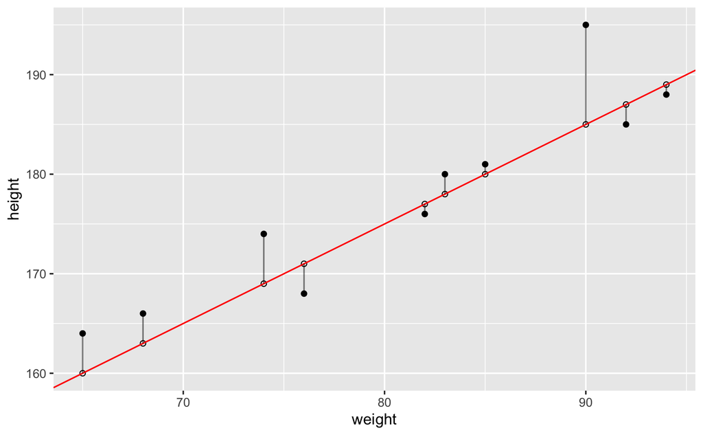

```r
sample %>%
  ggplot() +
  aes(x = weight, y = height) +
  geom_point() +
  geom_point(aes(x = weight, y = fit_height), shape = 1) +
  geom_abline(slope = 1, intercept = 95, col = "red") +
  geom_segment(aes(xend = weight, yend = fit_height), alpha = 0.5)
```

These vertical lines from the fitted lines to the recorded values show us the residual, the difference between the fitted height and the observed height.

# Least Squares Method

```r
sample <- sample %>%
  mutate(residual = height - fit_height)
sample
```

| weight | height | fit_height | residual |
| --- | --- | --- | --- |
| 82 | 176 | 177 | -1 |
| 65 | 164 | 160 | 4 |
| 85 | 181 | 180 | 1 |
| 76 | 168 | 171 | -3 |
| 90 | 195 | 185 | 10 |
| 92 | 185 | 187 | -2 |
| 68 | 166 | 163 | 3 |
| 83 | 180 | 178 | 2 |
| 94 | 188 | 189 | -1 |
| 74 | 174 | 169 | 5 |

When we fit a linear model to the data, we vary the intercept and the slope to make the residuals as small as possible.

# Summing the residuals does not work because the positive and negative values cancel out one another.

| sum_residuals |
| --- |
| 18 |

# Squaring the residuals makes all values positive so we can compare the size of the sum of the residuals across different lines

| sum_square_residuals |
| --- |
| 170 |

# Simple linear regression (lm method)

What we have done above is what R and ggplot use when finding a smoothed line with the lm method. With the lm method, programmed algorithms find th fit with the smallest sum of squared residuals

```r
model <- lm(formula = height ~ weight, data = sample)
model
```

```
Call:
lm(formula = height ~ weight, data = sample)

Coefficients:
(Intercept)       weight
   102.1758       0.9336
```

Same as

```r
new_model <- lm(formula = sample$height ~ sample$weight)
new_model
```

```
Call:
lm(formula = sample$height ~ sample$weight)

Coefficients:
  (Intercept)  sample$weight
     102.1758         0.9336
```

# Use fitted to get fitted values from a linear regression model

```r
class(fitted(model))
```

```
[1] "numeric"
```

This gives us a set of numeric values

# Use predict to get estimated outcome values for an explanatory variable value that was not included in the dataset.

```r
predict(model, newdata = predict_at)
```

```
       1        2        3
174.9927 186.1953 267.4142
```

# Using modelr in the tidyverse

# using modelr to find fitted heights and residuals

| weight | height | pred | resid |
| --- | --- | --- | --- |
| 82 | 176 | 178.7269 | -2.7269054 |
| 65 | 164 | 162.8565 | 1.1434504 |
| 85 | 181 | 181.5276 | -0.5275564 |
| 76 | 168 | 173.1256 | -5.1256033 |
| 90 | 195 | 186.1953 | 8.8046919 |
| 92 | 185 | 188.0624 | -3.0624088 |
| 68 | 166 | 165.6572 | 0.3427994 |
| 83 | 180 | 179.6605 | 0.3395443 |
| 94 | 188 | 189.9295 | -1.9295095 |
| 74 | 174 | 171.2585 | 2.7414974 |

# Plotting fitted lin with modelr

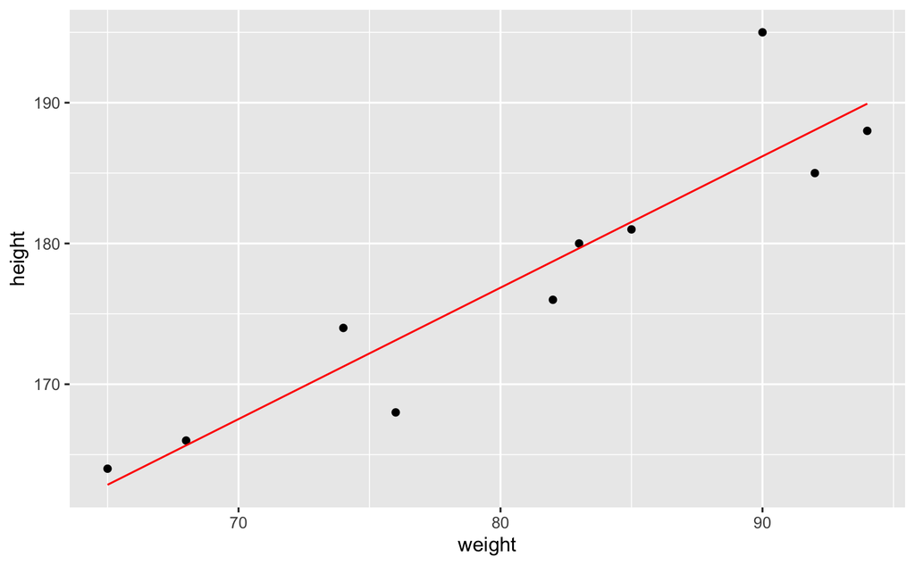

# We can plot this line without modelr just using our model and abline

But this can only give us a line, not predicted values at specific points.

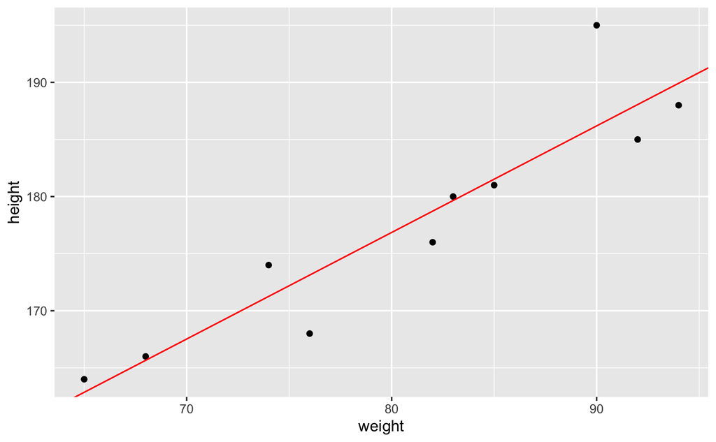

# Get predicted heights for weights from 50 - 120kg

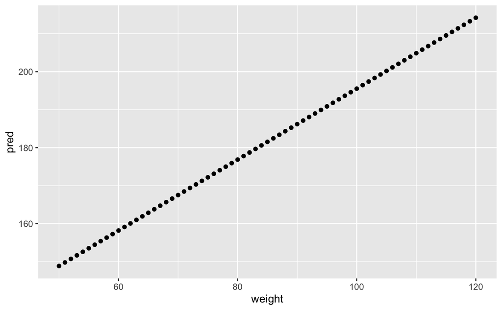

# The regression coefficient

b1, or the slope, tells us that for each 1 unit change in x, y changes by a set amount. In our example model, a 1kg increase in weight changes the predicted height by 0.9336cm

```r
model
```

```
Call:
lm(formula = height ~ weight, data = sample)

Coefficients:
(Intercept)       weight
   102.1758       0.9336
```